# Mini-Project 4 : Metagenomics

Author

Dorian Napolitano & Mateus Auza Cruz

Published

March 15, 2026

# 1 Introduction

## 1.1 Biological question

In this project, we analyze vaginal microbiome data generated by the ISALA citizen science project. The dataset contains **16S rRNA sequencing counts** for **200 randomly selected samples**.

Our objective is to explore the structure of the microbiome dataset and investigate whether groups of individuals exhibit **similar vaginal microbiota compositions**. Understanding these patterns may reveal common microbial community structures across individuals.

# 2 Data Loading and Preprocessing

In this section, we load the microbiome dataset and examine the structure of the object that stores the sequencing counts and associated metadata.

## 2.1 SummarizedExperiment structure

The dataset is stored in a SummarizedExperiment object, a common Bioconductor data structure used to organize high-throughput biological data. This object contains:

- the **count matrix** (microbial abundances),
- **sample metadata**, and
- potentially additional experimental information.

We load the dataset and inspect the structure of the object.

```r
library(SummarizedExperiment)

se = readRDS("isala_subset.Rds")
```

# 3 Exploratory Data Analysis

To gain an initial understanding of the dataset, we perform an exploratory analysis focusing on its size, structure, and general characteristics. This step provides an overview of the number of samples and taxa, the structure of the abundance matrix, metadata information, and key properties such as sequencing depth, sparsity, and taxa richness.

## 3.1 Number of samples and taxa

We begin by determining the number of samples and microbial taxa present in the dataset. The abundance matrix is extracted from the `SummarizedExperiment` object and its dimensions are summarized below.

```r
counts <- assay(se)

n_samples <- ncol(se)
n_taxa <- nrow(se)

dim_df <- data.frame(
  Metric = c("Number of samples", "Number of taxa"),
  Value = c(n_samples, n_taxa)
)

make_gt_table(
  dim_df,
  "Dataset Dimensions",
  "ISALA microbiome subset",
  60
)
```

Dataset Dimensions

ISALA microbiome subset

| Metric | Value |
| --- | --- |
| Number of samples | 200 |
| Number of taxa | 60 |

```r
preview_counts <- counts |>
  as.data.frame() |>
  dplyr::select(1:5) |>
  head()

make_gt_table(
  preview_counts,
  "Preview of Count Matrix",
  "First taxa across the first five samples",
  80
)
```

Preview of Count Matrix

First taxa across the first five samples

| SAMEA13411307 | SAMEA13410892 | SAMEA13413711 | SAMEA13412352 | SAMEA13412043 |
| --- | --- | --- | --- | --- |
| 0 | 0 | 0 | 0 | 0 |
| 0 | 0 | 0 | 60 | 4 |
| 0 | 0 | 0 | 0 | 0 |
| 0 | 0 | 13 | 0 | 0 |
| 0 | 0 | 0 | 0 | 0 |
| 90 | 5 | 1343 | 410 | 125 |

The count matrix is organized with taxa represented as rows and samples as columns. Each entry corresponds to the number of sequencing reads assigned to a specific taxon in a given sample.

To illustrate the structure of the data, a preview of the first taxa across the first five samples is displayed.

## 3.2 Metadata variables

Next, we examine the sample metadata, which contains additional descriptive variables associated with each sample. These variables may include biological, environmental, or technical information that can be used in downstream analyses.

```r
meta <- as.data.frame(colData(se))

meta_dim <- data.frame(
  Metric = c("Number of samples", "Number of metadata variables"),
  Value = c(nrow(meta), ncol(meta))
)

make_gt_table(
  meta_dim,
  "Metadata Dimensions",
  "ISALA microbiome subset",
  60
)
```

Metadata Dimensions

ISALA microbiome subset

| Metric | Value |
| --- | --- |
| Number of samples | 200 |
| Number of metadata variables | 26 |

```r
meta_preview <- head(meta)

make_gt_table(
  meta_preview,
  "Metadata Preview",
  "First samples and associated variables",
  90
)
```

Metadata Preview

First samples and associated variables

| general_age | health_bmi | health_antibiotic_3months | sexual_intercourse_24hours | technical_run_20201009_isala_cross_1 | technical_run_20201016_isala_cross_2 | technical_run_20201023_isala_cross_3 | technical_run_20201030_isala_cross_4 | technical_run_20201106_isala_cross_5 | technical_run_20201120_isala_cross_6 | technical_run_20201204_isala_cross_8 | technical_run_20201211_isala_cross_9 | technical_run_20210119_isala_cross_7 | technical_libsize | plate | volume | dna_conc | read_conc | read_conc_norm | lib_size | sample_month | transit_time | valencia_subcst | valencia_cst | max_genus1 | max_genus2 |
| --- | --- | --- | --- | --- | --- | --- | --- | --- | --- | --- | --- | --- | --- | --- | --- | --- | --- | --- | --- | --- | --- | --- | --- | --- | --- |
| 37 | 23.14815 | FALSE | FALSE | FALSE | TRUE | FALSE | FALSE | FALSE | FALSE | FALSE | FALSE | FALSE | 12350 | PlateAA | 1.454006 | 15.502 | 8493.776 | 0.9475659 | 12350 | 7 | 1 | I-B | I | L. crispatus | L. jensenii |
| 24 | 21.61281 | TRUE | FALSE | TRUE | FALSE | FALSE | FALSE | FALSE | FALSE | FALSE | FALSE | FALSE | 29744 | PlateAB | 2.315063 | 7.827 | 12848.029 | 0.9870559 | 29744 | 7 | 2 | III-A | III | L. iners | L. jensenii |
| 39 | 26.89232 | FALSE | FALSE | FALSE | FALSE | FALSE | FALSE | FALSE | FALSE | FALSE | TRUE | FALSE | 19930 | PlateAB | 2.981453 | 11.538 | 6684.661 | 0.7571235 | 19930 | 9 | 1 | IV-C0 | IV-C | Other | Prevotella |
| 28 | 23.66144 | TRUE | FALSE | FALSE | FALSE | FALSE | TRUE | FALSE | FALSE | FALSE | FALSE | FALSE | 19734 | PlateBA | 4.880278 | 7.768 | 4043.622 | 0.5573646 | 19734 | 7 | 7 | I-B | I | L. crispatus | L. jensenii |
| 32 | 20.31250 | TRUE | FALSE | FALSE | FALSE | FALSE | TRUE | FALSE | FALSE | FALSE | FALSE | FALSE | 36790 | PlateAA | 6.093876 | 6.221 | 6037.209 | 0.8321566 | 36790 | 7 | 3 | III-A | III | L. iners | L. jensenii |
| 35 | 21.96712 | TRUE | FALSE | FALSE | FALSE | TRUE | FALSE | FALSE | FALSE | FALSE | FALSE | FALSE | 15775 | PlateBA | 1.929866 | 12.747 | 8174.143 | 0.4597618 | 15775 | 7 | 3 | II | II | Prevotella | L. gasseri |

```r
var_names <- data.frame(Variable = names(meta))

make_gt_table(
  var_names,
  "Metadata Variables",
  "List of available sample metadata",
  60
)
```

Metadata Variables

List of available sample metadata

| Variable |
| --- |
| general_age |
| health_bmi |
| health_antibiotic_3months |
| sexual_intercourse_24hours |
| technical_run_20201009_isala_cross_1 |
| technical_run_20201016_isala_cross_2 |
| technical_run_20201023_isala_cross_3 |
| technical_run_20201030_isala_cross_4 |
| technical_run_20201106_isala_cross_5 |
| technical_run_20201120_isala_cross_6 |
| technical_run_20201204_isala_cross_8 |
| technical_run_20201211_isala_cross_9 |
| technical_run_20210119_isala_cross_7 |
| technical_libsize |
| plate |
| volume |
| dna_conc |
| read_conc |
| read_conc_norm |
| lib_size |
| sample_month |
| transit_time |
| valencia_subcst |
| valencia_cst |
| max_genus1 |
| max_genus2 |

The metadata table contains one row per sample and multiple variables describing sample characteristics. A preview of the metadata and the full list of available variables are shown above.

### 3.2.1 Distribution of sequencing counts

Sequencing depth represents the total number of reads obtained for each sample. Assessing its distribution helps evaluate whether sequencing coverage is consistent across samples.

```r
sample_depth <- colSums(counts)

summary_df <- data.frame(
  Statistic = names(summary(sample_depth)),
  Value = as.numeric(summary(sample_depth))
)

make_gt_table(
  summary_df,
  "Sequencing Depth Summary",
  "Total reads per sample",
  60
)
```

Sequencing Depth Summary

Total reads per sample

| Statistic | Value |
| --- | --- |
| Min. | 3093.00 |
| 1st Qu. | 14775.00 |
| Median | 22579.00 |
| Mean | 23114.97 |
| 3rd Qu. | 30900.75 |
| Max. | 86998.00 |

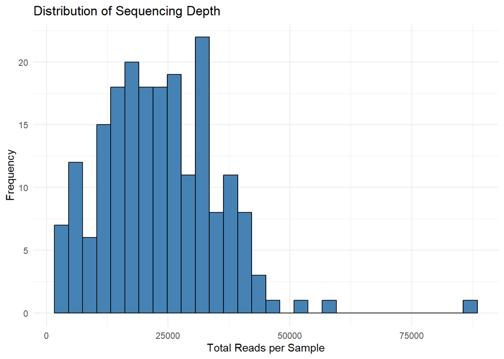

```r
depth_df <- data.frame(sample_depth)

ggplot(depth_df, aes(x = sample_depth)) +
  geom_histogram(bins = 30, color = "black", fill = "steelblue") +
  labs(
    title = "Distribution of Sequencing Depth",
    x = "Total Reads per Sample",
    y = "Frequency"
  ) +
  theme_minimal()
```

Overall, sequencing depth appears relatively consistent across most samples, with the majority of values falling between approximately 15,000 and 31,000 reads, corresponding to the first and third quartiles. This indicates that about half of the samples lie within this interval.

However, the distribution exhibits a right-skewed tail, with a small number of samples having substantially higher read counts. The maximum sequencing depth approaches 87,000 reads, suggesting the presence of a few high-coverage outliers.

## 3.3 Sparsity of counts

Microbiome datasets are typically highly sparse, as many microbial taxa are absent in most samples. To quantify this property, we compute the proportion of zero values in the abundance matrix.

```r
mean(counts == 0)
```

```
[1] 0.7031667
```

Approximately 70% of the entries in the count matrix are zero, indicating that most taxa are not detected in most samples. This level of sparsity is common in microbiome sequencing data.

## 3.4 Taxa richness per sample

We next examine taxa richness, defined here as the number of taxa detected in each sample. This measure provides a simple indicator of microbial diversity across individuals.

```r
taxa_per_sample <- colSums(counts > 0)

summary_df2 <- data.frame(
  Statistic = names(summary(taxa_per_sample)),
  Value = as.numeric(summary(taxa_per_sample))
)

make_gt_table(
  summary_df2,
  "Taxa Richness Summary",
  "Number of detected taxa per sample",
  60
)
```

Taxa Richness Summary

Number of detected taxa per sample

| Statistic | Value |
| --- | --- |
| Min. | 1.00 |
| 1st Qu. | 12.00 |
| Median | 18.00 |
| Mean | 17.81 |
| 3rd Qu. | 24.00 |
| Max. | 38.00 |

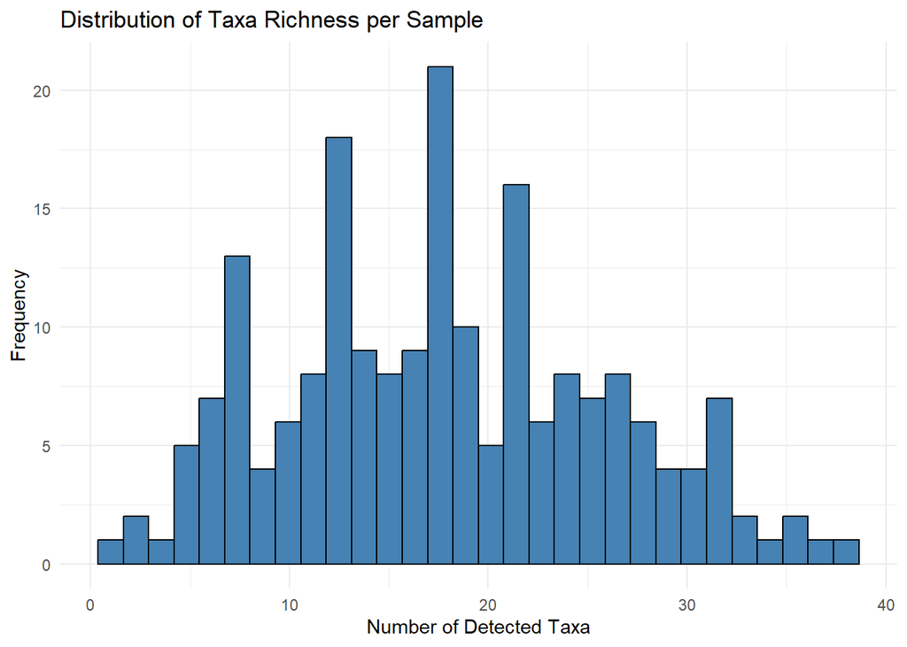

```r
taxa_df <- data.frame(taxa_per_sample)

ggplot(taxa_df, aes(x = taxa_per_sample)) +
  geom_histogram(bins = 30, color = "black", fill = "steelblue") +
  labs(
    title = "Distribution of Taxa Richness per Sample",
    x = "Number of Detected Taxa",
    y = "Frequency"
  ) +
  theme_minimal()
```

The results show moderate variation in taxa richness across samples. Most individuals have between 12 and 24 detected taxa, although some samples contain substantially more or fewer taxa.

This variability suggests differences in microbial community composition between individuals, potentially reflecting biological variation, host-related factors, or environmental influences.

## 3.5 Conclusion of exploratory analysis

The exploratory analysis indicates that the dataset contains 200 samples with diverse microbial compositions. Sequencing depth is generally consistent across samples, although a small number of high-read-count outliers are present. The abundance matrix is highly sparse, with approximately 70% zero values, a typical characteristic of microbiome datasets.

Taxa richness varies moderately across individuals, indicating differences in microbial diversity among samples. These observations support the hypothesis that distinct microbial community structures may exist within the dataset.

In the following sections, we therefore investigate whether clusters of individuals with similar microbiota compositions can be identified.

# 4 Alpha Diversity Analysis

Alpha diversity measures the diversity of microbial communities within individual samples. It reflects both the richness (number of taxa) and the evenness (distribution of abundances) of microbial communities.

In this section, we compute three commonly used alpha diversity metrics:

- Taxa richness: number of detected taxa in each sample
- Shannon index: accounts for both richness and evenness
- Simpson index: measures the probability that two randomly selected reads belong to different taxa

```r
counts <- assay(se)

richness <- colSums(counts > 0)
shannon  <- diversity(t(counts), index = "shannon")
simpson  <- diversity(t(counts), index = "simpson")


alpha_div <- data.frame(
  richness = richness,
  shannon  = shannon,
  simpson  = simpson
)

summary(alpha_div)
```

```
    richness        shannon          simpson
 Min.   : 1.00   Min.   :0.0000   Min.   :0.0000
 1st Qu.:12.00   1st Qu.:0.3141   1st Qu.:0.1013
 Median :18.00   Median :0.7700   Median :0.3869
 Mean   :17.81   Mean   :0.8595   Mean   :0.3699
 3rd Qu.:24.00   3rd Qu.:1.2991   3rd Qu.:0.5838
 Max.   :38.00   Max.   :2.5010   Max.   :0.8891
```

From the summary statistics, several observations can be made.

First, taxa richness ranges from 1 to 38 detected taxa per sample, with a median of approximately 18 taxa and a mean around 17 taxa. This suggests that most samples contain a moderate number of microbial taxa, although there is noticeable variability between individuals.

Second, the Shannon diversity index ranges from 0 to approximately 2.5, with a median close to 0.77. These relatively low values indicate that many samples are likely dominated by a small number of taxa, meaning that microbial communities are not evenly distributed.

Finally, the Simpson diversity index ranges from 0 to approximately 0.89, with a median around 0.38. This indicates that while some samples contain more balanced microbial communities, others are strongly dominated by only a few taxa.

Overall, these results suggest moderate variation in microbial diversity across individuals, with many samples showing relatively low evenness in taxon abundances.

## 4.1 Distribution of Alpha Diversity

To better understand the variability in microbial diversity across samples, we visualize the distributions of the computed diversity indices.

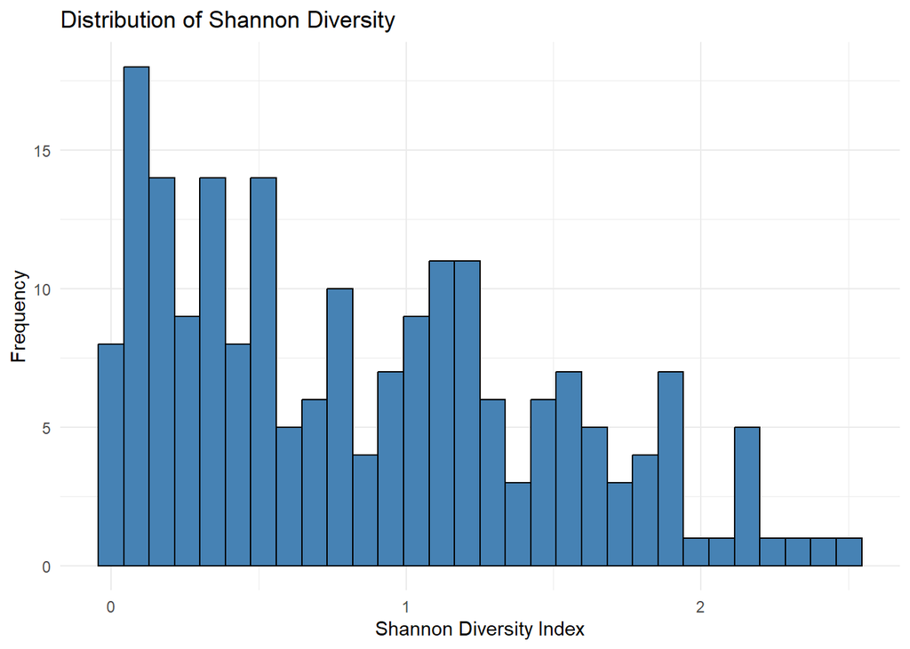

```r
ggplot(alpha_div, aes(x = shannon)) +
  geom_histogram(bins = 30, color = "black", fill = "steelblue") +
  labs(
    title = "Distribution of Shannon Diversity",
    x = "Shannon Diversity Index",
    y = "Frequency"
  ) +
  theme_minimal()
```

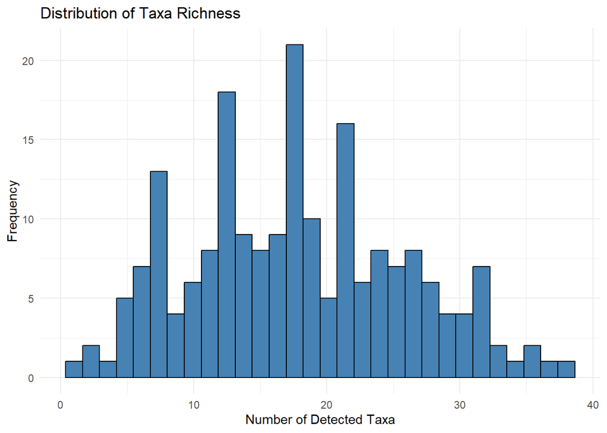

```r
ggplot(alpha_div, aes(richness)) +
  geom_histogram(bins = 30, color = "black", fill = "steelblue") +
  labs(title = "Distribution of Taxa Richness",
       x = "Number of Detected Taxa",
       y = "Frequency") +
  theme_minimal()
```

The histograms illustrate how diversity varies across individuals. The Shannon diversity distribution shows that most samples exhibit low to moderate diversity, with relatively few samples displaying higher diversity values. Similarly, the taxa richness distribution indicates that the majority of samples contain between roughly 10 and 25 detected taxa, while only a small number of samples show very low or very high richness.

These patterns suggest that although most individuals share broadly similar diversity levels, there remains considerable variability in microbial community complexity across samples.

# 5 Beta Diversity and PCoA

While alpha diversity focuses on variation within individual samples, beta diversity measures differences in microbial community composition between samples.

To quantify these differences, we compute a Bray–Curtis dissimilarity matrix, a widely used distance metric for ecological count data that accounts for differences in species abundances between samples.

We then apply Principal Coordinates Analysis (PCoA) to reduce the high-dimensional dissimilarity matrix into a two-dimensional representation. This allows us to visually explore similarities and differences between microbial communities.

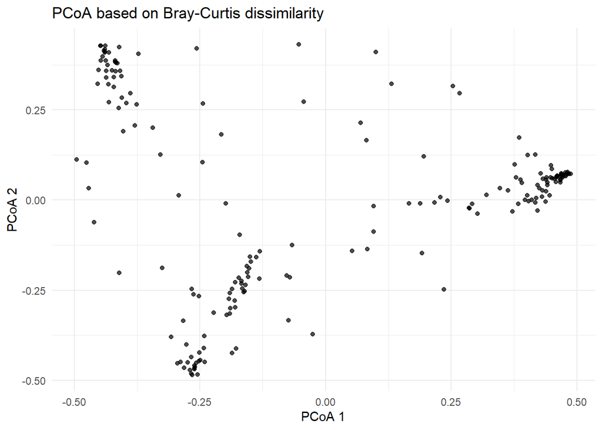

```r
# Bray-Curtis distance
bray_dist <- vegdist(t(counts), method = "bray")

# PCoA
pcoa <- cmdscale(bray_dist, k = 2, eig = TRUE)

pcoa_df <- data.frame(
  PC1 = pcoa$points[,1],
  PC2 = pcoa$points[,2]
)

ggplot(pcoa_df, aes(PC1, PC2)) +
  geom_point(alpha = 0.7) +
  labs(title = "PCoA based on Bray-Curtis dissimilarity",
       x = "PCoA 1",
       y = "PCoA 2") +
  theme_minimal()
```

The resulting PCoA plot represents each sample as a point in a two-dimensional space. Samples that appear closer together have more similar microbial compositions, while those that are farther apart exhibit greater differences.

The PCoA visualization suggests the presence of multiple distinct microbial community structures. Several groups of samples appear to cluster together, indicating that certain individuals share similar microbiome compositions, while larger distances between clusters reflect substantial compositional differences.

# 6 Unsupervised Clustering of Microbiome Samples

To formally identify potential groups of individuals with similar vaginal microbiome compositions, we perform an unsupervised clustering analysis. This approach identifies natural patterns in the data without relying on predefined labels.

Because microbiome data consist of compositional abundance counts, we again use the Bray–Curtis dissimilarity as the measure of distance between samples.

## 6.1 Clustering Method

We apply hierarchical clustering using Ward’s linkage method, which iteratively groups samples based on their similarity in microbial composition while minimizing within-cluster variation.

The resulting dendrogram provides a hierarchical representation of the relationships between samples, allowing us to explore potential clustering structures.

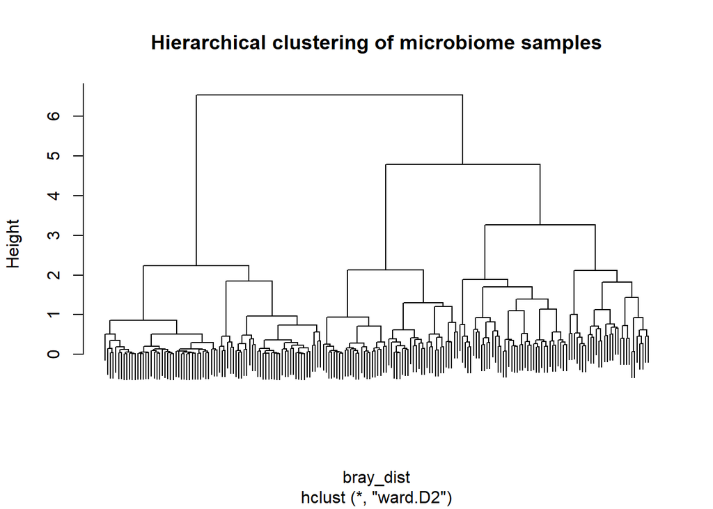

```r
# Bray-Curtis distance matrix
bray_dist <- vegdist(t(counts), method = "bray")

# hierarchical clustering
hc <- hclust(bray_dist, method = "ward.D2")

# dendrogram
plot(hc, labels = FALSE, main = "Hierarchical clustering of microbiome samples")
```

## 6.2 Choosing the Number of Clusters

To determine an appropriate number of clusters, we use the silhouette method, which evaluates how well each sample fits within its assigned cluster compared to other clusters.

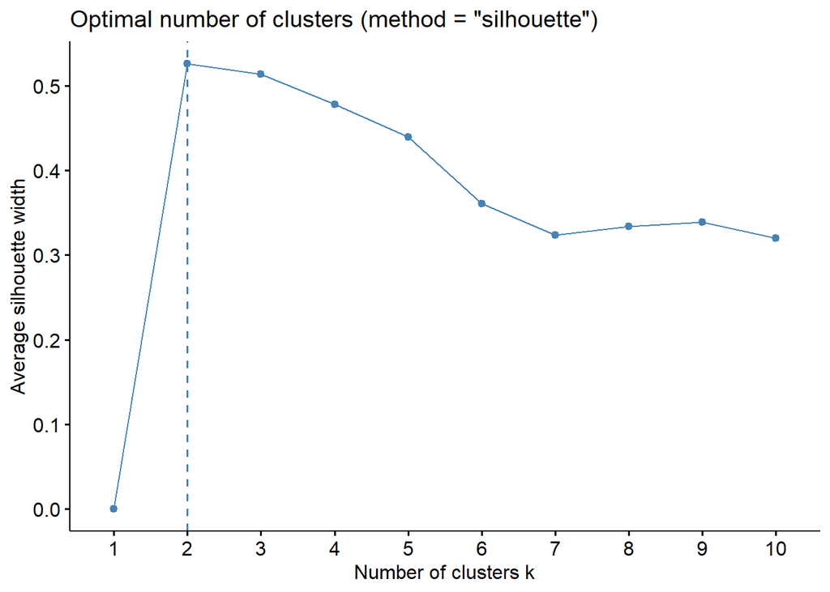

```r
# silhouette analysis
fviz_nbclust(as.matrix(bray_dist),
             FUN = hcut,
             method = "silhouette")
```

The silhouette analysis suggests that two clusters (k = 2) provide the best separation of the data. We therefore partition the dendrogram into two clusters and examine the number of samples assigned to each group.

```r
k=2
clusters <- cutree(hc, k = k)
cluster_table <- as.data.frame(table(clusters))


cluster_table %>%
  gt() %>%
  cols_label(
    clusters = "Cluster",
    Freq = "Number of Samples"
  )
```

| Cluster | Number of Samples |
| --- | --- |
| 1 | 120 |
| 2 | 80 |

# 7 Visualizing Clusters on the PCoA

To facilitate interpretation of the clustering results, we overlay the cluster assignments on the PCoA plot.

Coloring the samples by cluster membership allows us to visually assess how well the clusters correspond to the patterns observed in the ordination space. Samples belonging to the same cluster tend to group together in the PCoA plot, supporting the presence of distinct microbial community structures.

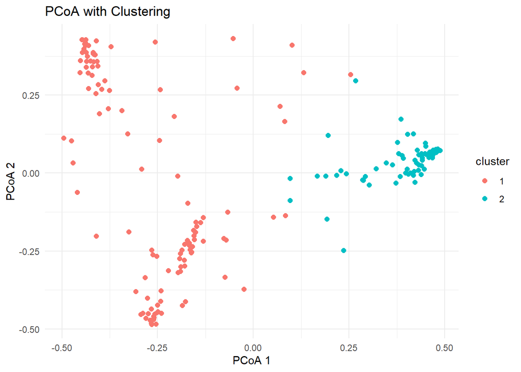

```r
pcoa_df$cluster <- as.factor(clusters)

ggplot(pcoa_df, aes(PC1, PC2, color = cluster)) +
  geom_point(size = 2) +
  labs(title = "PCoA with Clustering",
       x = "PCoA 1",
       y = "PCoA 2") +
  theme_minimal()
```

# 8 Conclusion

The exploratory and diversity analyses reveal substantial variability in vaginal microbiome composition across individuals. Although many samples share similar levels of microbial diversity, the beta diversity analysis highlights important differences in community composition between samples.

Hierarchical clustering based on Bray–Curtis dissimilarity identified two primary clusters of individuals, suggesting the presence of distinct microbial community structures within the dataset. These clusters likely correspond to different microbiome profiles characterized by varying dominant taxa.

Overall, the results support the hypothesis that individuals can be grouped according to similarities in their vaginal microbiota composition.

Future analyses could further investigate which microbial taxa drive these differences and whether metadata variables such as clinical or environmental factors are associated with the observed clustering patterns.